# Stack Data Structure

## Definisi

Stack adalah struktur data linier yang menerapkan prinsip **LIFO (Last In First Out)** atau sering juga disebut **FILO (First In Last Out)**, di mana elemen yang terakhir dimasukkan akan menjadi elemen pertama yang dikeluarkan. Pada struktur data ini, proses penambahan (push) dan penghapusan (pop) data hanya dapat dilakukan pada satu ujung yang sama, yaitu bagian yang disebut top.

> Elemen yang berada paling dekat dengan posisi top merupakan elemen yang terakhir dimasukkan, sedangkan elemen yang semakin jauh dari top menunjukkan bahwa elemen tersebut telah berada lebih lama di dalam stack. Ketika sebuah elemen baru ditambahkan, elemen tersebut akan ditempatkan di posisi top, dan jika terjadi proses penghapusan, maka elemen yang berada di top itulah yang akan dikeluarkan terlebih dahulu.

Sebuah stack dapat diimplementasikan menggunakan array di mana kita menyimpan:

- Sebuah array bilangan bulat untuk menyimpan elemen.
- Kapasitas variabel untuk mewakili ukuran maksimum tumpukan.
- Variabel `top` digunakan untuk melacak indeks elemen teratas. Awalnya, `top = -1` menunjukkan tumpukan kosong.

## Konsep

Ini berperilaku seperti tumpukan piring, di mana piring terakhir yang ditambahkan adalah piring pertama yang dikeluarkan. Bayangkan seperti ini:

- Menambahkan elemen ke dalam tumpukan itu seperti menambahkan piring baru di atasnya.
- Mengeluarkan elemen dari tumpukan akan menghapus pelat teratas.

[figure not shown]

```
Konsep stack ini juga dapat ditemui pada permasalahan sehari-hari, misalkan tumpukan buku pada Gambar 1 berikut.
```

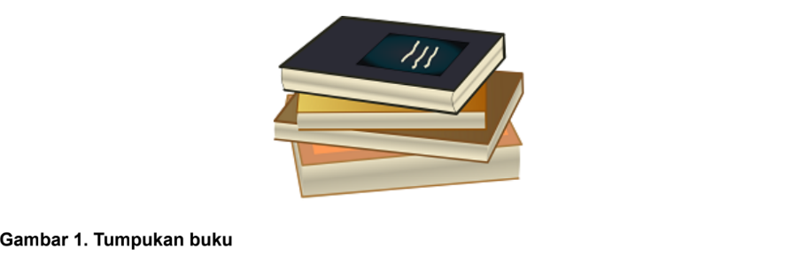

```
Jika kita ingin mengambil buku pada tumpukan buku tersebut, maka buku yang dapat kita ambiladalah buku yang berada di posisi teratas. Jika ingin mengambil buku yang berada di posisi paling bawah, maka kita harus mengambil buku-buku yang berada di posisi atasnya terlebih dahulu. Begitu juga ketika terdapat penambahan buku baru, maka buku baru ini akan berada di posisi paling atas.
```

## Prinsip LIFO (Last In First Out)

Prinsip LIFO berarti bahwa elemen terakhir yang ditambahkan ke dalam tumpukan adalah elemen pertama yang dihapus.

- Elemen-elemen baru selalu ditambahkan di atasnya.
- Pelepasan (pop) juga hanya terjadi dari atas.
- Ini memastikan urutan yang ketat: yang terakhir masuk → yang pertama keluar.

### Contoh nyata penerapan LIFO:

1. Tumpukan piring – Piring terakhir yang diletakkan di atas adalah piring pertama yang Anda ambil.
2. Tumpukan buku – Buku ditambahkan dan dikeluarkan dari atas, jadi buku terakhir yang diletakkan adalah buku pertama yang diambil.

### Terminologi Dasar Stack

- Top : Posisi elemen yang paling baru dimasukkan. Penyisipan (push) dan penghapusan (pop) selalu dilakukan di bagian atas.
- Ukuran : Mengacu pada jumlah elemen yang saat ini ada di dalam tumpukan

## Jenis-Jenis Stack

### 1. Fixed Size Stack

- Tumpukan dengan ukuran tetap memiliki kapasitas yang telah ditentukan sebelumnya.
- Setelah terisi penuh, tidak ada lagi elemen yang dapat ditambahkan (ini menyebabkan overflow ).
- Jika tumpukan kosong dan kita mencoba menghapus elemen, hal itu menyebabkan underflow .
- Biasanya diimplementasikan menggunakan array statis.

> Contoh: Mendeklarasikan tumpukan berukuran 10 menggunakan array.

### 2. Dynamic Size Stack

- Tumpukan dengan ukuran dinamis dapat tumbuh dan menyusut secara otomatis sesuai kebutuhan.
- Jika tumpukan sudah penuh, kapasitasnya akan diperluas untuk memungkinkan lebih banyak elemen masuk.
- Saat elemen dihapus, penggunaan memori juga dapat menyusut.
- Dapat diimplementasikan menggunakan:

  ```
    -> Linked List → tumbuh/menyusut secara alami.

    -> Array Dinamis (seperti vector di C++ atau ArrayList di Java) → mengubah ukurannya secara otomatis.
  ```

> Contoh: Implementasi stack menggunakan linked list atau resizable array.

Catatan: Dalam praktiknya, kami umumnya menggunakan tumpukan dinamis karena dapat membesar atau mengecil sesuai kebutuhan tanpa masalah kelebihan kapasitas.

## Aplikasi Stack

Stack adalah struktur data linier di mana penyisipan elemen baru dan penghapusan elemen yang sudah ada terjadi di ujung yang sama, yang diwakili oleh bagian atas stack .

Aplikasi stack sangat beragam, mewakili struktur data dinamis dengan berbagai kegunaan, beberapa di antaranya disebutkan di bawah ini:

1. Panggilan Fungsi

Stack mengelola fungsi-fungsi "aktif" dalam sebuah program. Ketika sebuah fungsi dipanggil, status eksekusinya dimasukkan ke dalam stack; ketika selesai, status tersebut dikeluarkan (pop) untuk mengembalikan kendali ke pemanggil.

```
Contoh: Dalam program di mana Main() memanggil CalculateBill(), yang kemudian memanggil ApplyDiscount(), stack memastikan bahwa setelah diskon dihitung, program tahu persis bagaimana cara kembali ke tengah fungsi penagihan.
```

2. Rekursi

Karena rekursi pada dasarnya adalah fungsi yang memanggil dirinya sendiri, tumpukan menyimpan "cuplikan" dari setiap panggilan (termasuk variabel lokal) sehingga program tidak kehilangan posisinya.

```
Contoh: Dalam menghitung Faktorial (n!), tumpukan menyimpan nilai n untuk setiap panggilan bersarang. Untuk 3!, tumpukan memasukkan 3, kemudian 2, lalu 1. Setelah mencapai kasus dasar, tumpukan mengeluarkan nilai-nilai tersebut untuk dikalikan dalam urutan terbalik (1 x 2 x 3).
```

3. Evaluasi Ekspresi

Stack digunakan oleh compiler dan kalkulator untuk mengatur urutan operasi tanpa memerlukan tanda kurung yang rumit.

```
Contoh: Untuk menyelesaikan ekspresi postfix "3 4 + 5 *", sebuah tumpukan memasukkan 3 dan 4, mengeluarkannya untuk menjumlahkannya (menghasilkan 7), memasukkan kembali 7, kemudian memasukkan 5, dan akhirnya mengeluarkan keduanya untuk mengalikannya sehingga totalnya menjadi 35.
```

4. Penguraian Sintaksis

Susunan tanda kurung sangat cocok untuk "menyeimbangkan" simbol. Susunan ini memastikan bahwa setiap tanda kurung buka memiliki tanda kurung tutup yang sesuai dalam urutan yang benar.

```
Contoh: IDE menggunakan tumpukan (stack) untuk memeriksa kode seperti " if (a > b) { print(c); } " . IDE menambahkan ' ( ' dan ' { ' ke dalam tumpukan saat menemukannya. Ketika menemukan ' ) ' dan ' } ', IDE mengeluarkan elemen teratas untuk memastikan tipe datanya cocok. Jika tumpukan kosong di akhir, sintaksnya valid.
```

5. Manajemen Memori

"Stack" adalah area khusus pada RAM yang digunakan untuk alokasi variabel otomatis. Stack sangat cepat karena hanya mengalokasikan dan membebaskan memori dalam urutan Last-In, First-Out (LIFO) yang ketat.

```
Contoh: Saat Anda mendeklarasikan " int x = 10; " di dalam fungsi Java atau C++, memori tersebut dialokasikan di Stack. Segera setelah tanda kurung kurawal penutup fungsi ' } ' tercapai, memori tersebut secara otomatis diklaim kembali oleh sistem tanpa perlu pembersihan manual.
```

Keuntungan:

- Efisiensi Waktu & Memori : Operasi push dan pop pada stack dapat dilakukan dalam waktu konstan O(1), memungkinkan akses data yang efisien, dan efisien dalam penggunaan memori karena hanya menyimpan elemen yang di-push, dibandingkan dengan struktur data lainnya.
- Last-In, First-Out (LIFO) : Stack mengikuti prinsip LIFO, memastikan elemen terakhir yang ditambahkan adalah elemen pertama yang dihapus. Perilaku ini berguna dalam skenario seperti panggilan fungsi dan evaluasi ekspresi.

Kekurangan:

- Akses terbatas: Elemen dalam tumpukan hanya dapat diakses dari atas, yang menyulitkan untuk mengambil atau memodifikasi elemen di tengah.
- Potensi terjadinya overflow : Mendorong lebih banyak elemen ke dalam tumpukan daripada yang dapat ditampung akan mengakibatkan kesalahan overflow, yang menyebabkan hilangnya data.

## Operasi Umum pada Stack:

Untuk melakukan manipulasi pada sebuah stack, terdapat beberapa operasi yang disediakan untuk kita.

- Gunakan push() untuk memasukkan elemen ke dalam tumpukan.
- Gunakan pop() untuk menghapus elemen dari tumpukan.
- top() Mengembalikan elemen teratas dari tumpukan.
- isEmpty() mengembalikan nilai true jika stack kosong, jika tidak, mengembalikan nilai false.
- size() mengembalikan ukuran tumpukan.

### 1. Operasi Push pada Stack:

```
Ilustrasi proses penambahan data atau yang dikenal dengan istilah push dapat dilihat pada Gambar berikut.
```

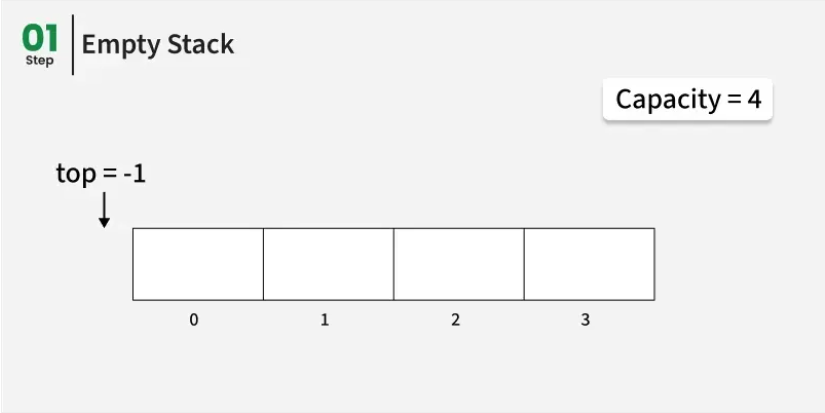

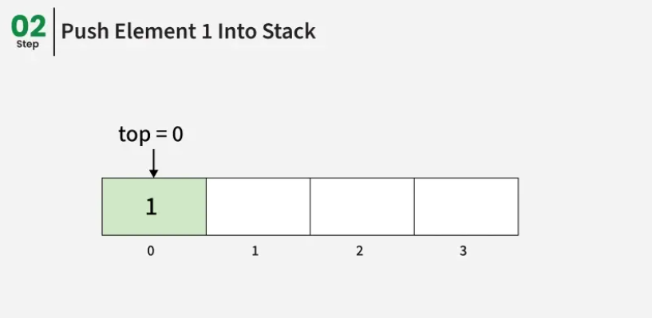

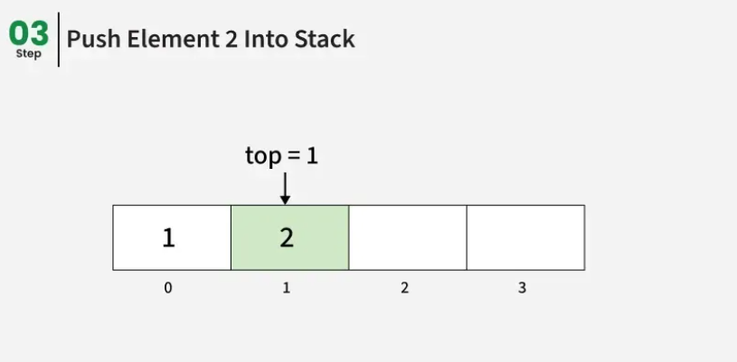

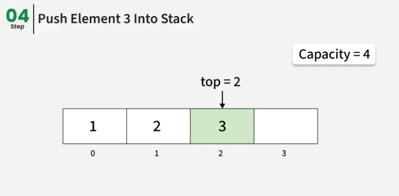

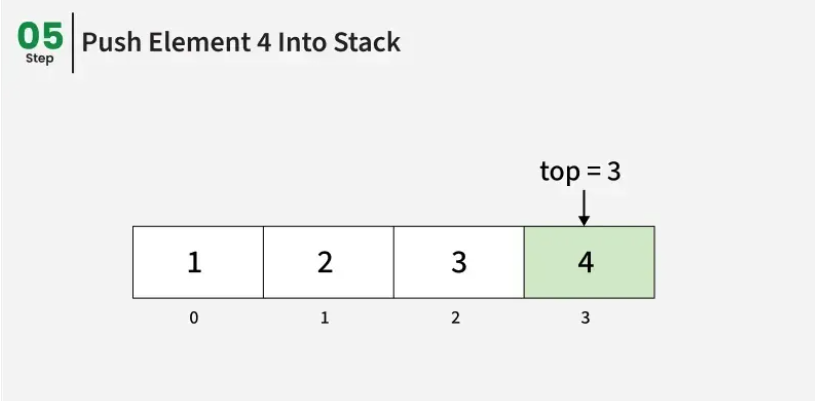

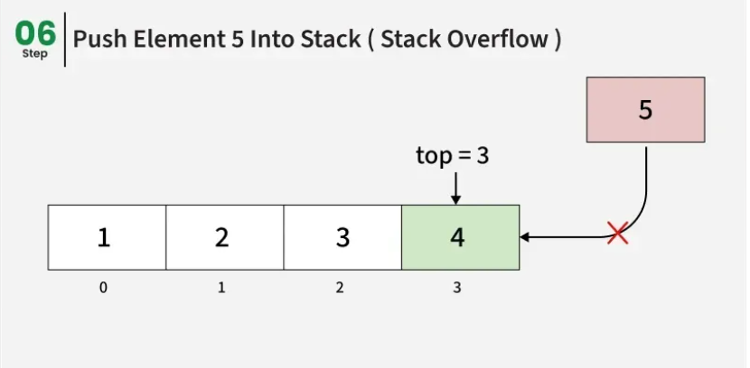

Menambahkan item ke dalam tumpukan. Jika tumpukan sudah penuh, maka dikatakan terjadi kondisi Overflow .

- Sebelum memasukkan elemen ke dalam tumpukan, kita periksa terlebih dahulu apakah tumpukan sudah penuh.
- Jika tumpukan sudah penuh (top == capacity-1), maka terjadi Stack Overflow dan kita tidak dapat memasukkan elemen ke dalam tumpukan.
- Jika tidak, kita menambah nilai top sebesar 1 (top = top + 1) dan nilai baru tersebut dimasukkan pada posisi teratas.
- Elemen-elemen dapat dimasukkan ke dalam tumpukan hingga mencapai kapasitas tumpukan.

```python
def push(self, x):

    if self.top == self.capacity - 1:
        print("Stack Overflow")
        return

    self.top += 1

    self.arr[self.top] = x
```

`Kompleksitas Waktu: O(1)`

`Ruang Tambahan: O(1)`

### 2. Operasi Ppp pada Stack:

```
Sedangkan proses penghapusan data atau yang dikenal dengan istilah pop dapat dilihat pada Gambar berikut.
```

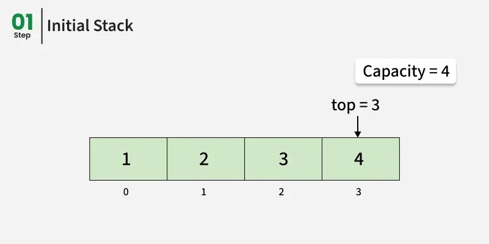

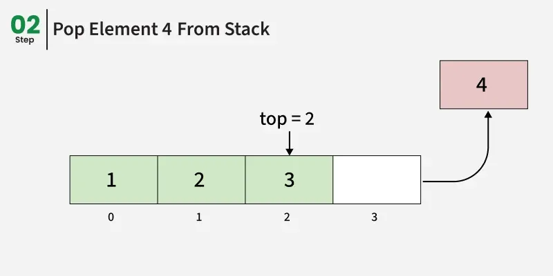

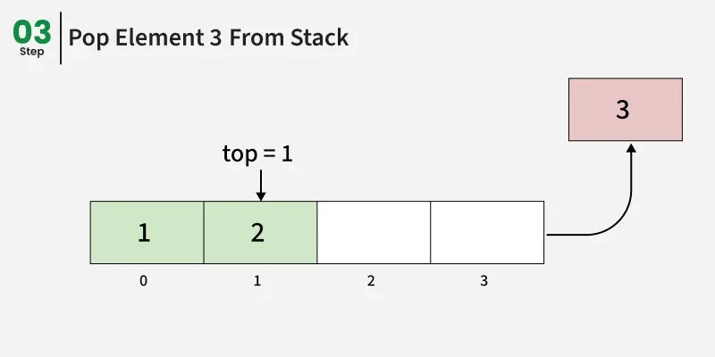

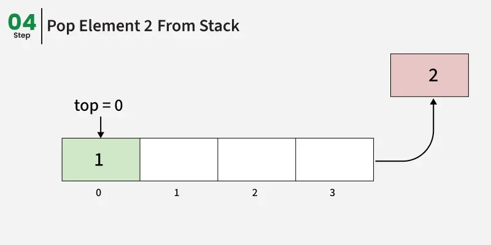

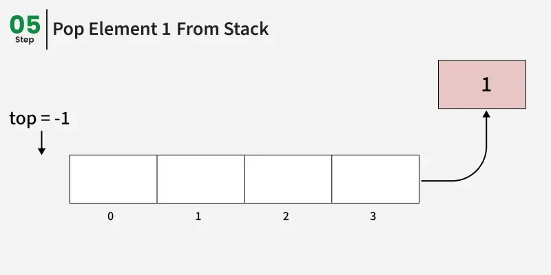

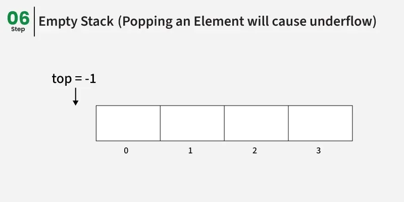

Menghapus item dari tumpukan. Item dikeluarkan dalam urutan terbalik dari urutan saat dimasukkan. Jika tumpukan kosong, maka dikatakan terjadi kondisi Underflow .

- Sebelum mengeluarkan elemen dari tumpukan, kita periksa apakah tumpukan kosong.
- Jika tumpukan kosong (top == -1), maka terjadi Stack Underflow dan kita tidak dapat menghapus elemen apa pun dari tumpukan.
- Jika tidak, kita menyimpan nilai di top, mengurangi nilai top sebesar 1 (top = top – 1) dan mengembalikan nilai top yang tersimpan.

```python
def pop(self):

    if self.top == -1:
        print("Stack Underflow")
        return -1

    value = self.arr[self.top]
    self.top -= 1

    return value
```

`Kompleksitas Waktu: O(1)`

`Ruang Tambahan: O(1)`

### 3. Operasi Top atau Peek pada Stack:

Mengembalikan elemen teratas dari tumpukan.

- Sebelum mengembalikan elemen teratas dari tumpukan, kita periksa apakah tumpukan tersebut kosong.
- Jika tumpukan kosong (top == -1), kita cukup mencetak “Tumpukan kosong”.
- Jika tidak, kita kembalikan elemen yang tersimpan di `indeks = top` .

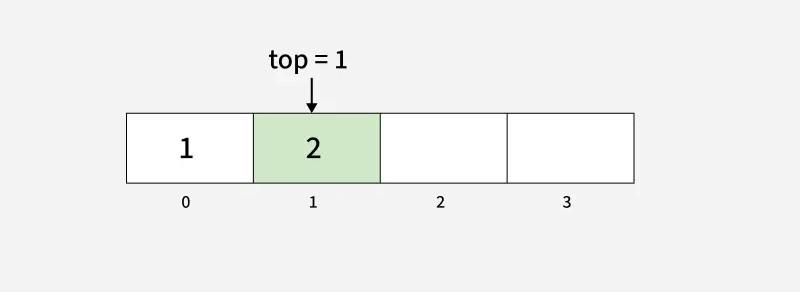

```python
def peek(self):

    if self.top == -1:
        print("Stack is Empty")
        return -1

    return self.arr[self.top]
```

`Kompleksitas Waktu: O(1)`

`Ruang Tambahan: O(1)`

### 4. Operasi isEmpty di Stack:

Mengembalikan nilai true jika tumpukan kosong, jika tidak, mengembalikan nilai false.

- Periksa nilai `top` di dalam tumpukan.
- Jika (top == -1), maka tumpukan kosong, jadi kembalikan true.
- Jika tidak, tumpukan tidak kosong sehingga mengembalikan nilai false.

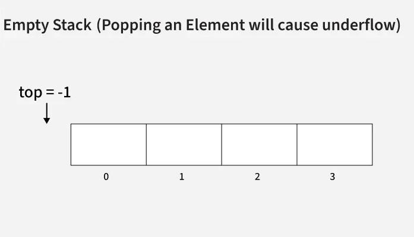

```python
def isEmpty(self):

    return self.top == -1
```

`Kompleksitas Waktu: O(1)`

`Ruang Tambahan: O(1)`

### 5. Operasi isFull di Stack:

Mengembalikan nilai true jika stack penuh, jika tidak, false.

- Periksa nilai `top` di dalam tumpukan.
- Jika (top == capacity-1), maka stack sudah penuh, jadi kembalikan true.
- Jika tidak, berarti stack belum penuh sehingga mengembalikan nilai false.

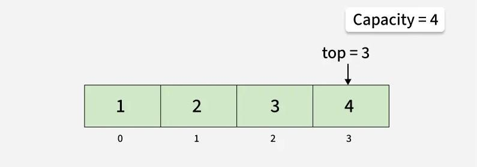

`Kompleksitas Waktu: O(1)`

`Ruang Tambahan: O(1)`

### Implementasi Lengkap Stack menggunakan Array:

```python
class myStack:
    # constructor
    def __init__(self, cap):
        self.capacity = cap
        self.arr = [0] * self.capacity
        self.top = -1

    # push operation
    def push(self, x):
        if self.top == self.capacity - 1:
            print("Stack Overflow")
            return
        self.top += 1
        self.arr[self.top] = x

    # pop operation
    def pop(self):
        if self.top == -1:
            print("Stack Underflow")
            return -1
        val = self.arr[self.top]
        self.top -= 1
        return val

    # peek (or top) operation
    def peek(self):
        if self.top == -1:
            print("Stack is Empty")
            return -1
        return self.arr[self.top]

    # check if stack is empty
    def isEmpty(self):
        return self.top == -1

    # check if stack is full
    def isFull(self):
        return self.top == self.capacity - 1


if __name__ == "__main__":
    st = myStack(4)

    # pushing elements
    st.push(1)
    st.push(2)
    st.push(3)
    st.push(4)

    # popping one element
    print("Popped:", st.pop())

    # checking top element
    print("Top element:", st.peek())

    # checking if stack is empty
    print("Is stack empty: ", "Yes" if st.isEmpty() else "No")

    # checking if stack is full
    print("Is stack full: ", "Yes" if st.isFull() else "No")
```

```
Popped: 4
Top element: 3
Is stack empty:  No
Is stack full:  No
```

### Implementasi Stack menggunakan Array Dinamis

Saat menggunakan array berukuran tetap, tumpukan memiliki kapasitas maksimum yang tidak dapat bertambah melebihi ukuran awalnya. Untuk mengatasi keterbatasan ini, kita dapat menggunakan array dinamis . Array dinamis secara otomatis mengubah ukurannya sendiri saat elemen ditambahkan atau dihapus, yang membuat tumpukan lebih fleksibel.

- Dalam C++, kita dapat menggunakan vektor.
- Di Java, kita bisa menggunakan ArrayList.
- Di Python, kita bisa menggunakan list.
- Dalam C#, kita dapat menggunakan List.
- Dalam JavaScript, kita dapat menggunakan Array.

```python
class myStack:
    def __init__(self):
        self.arr = []

    # push operation
    def push(self, x):
        self.arr.append(x)

    # pop operation
    def pop(self):
        if not self.arr:
            print("Stack Underflow")
            return -1
        return self.arr.pop()

    # peek operation
    def peek(self):
        if not self.arr:
            print("Stack is Empty")
            return -1
        return self.arr[-1]

    # check if stack is empty
    def isEmpty(self):
        return len(self.arr) == 0

    # current size
    def size(self):
        return len(self.arr)


if __name__ == "__main__":
    st = myStack()

    # pushing elements
    st.push(1)
    st.push(2)
    st.push(3)
    st.push(4)

    # popping one element
    print("Popped:", st.pop())

    # checking top element
    print("Top element:", st.peek())

    # checking if stack is empty
    print("Is stack empty:", "Yes" if st.isEmpty() else "No")

    # checking current size
    print("Current size:", st.size())
```

```
Popped: 4
Top element: 3
Is stack empty: No
Current size: 3
```

### Stack Ukuran Tetap vs Stack Ukuran Dinamis

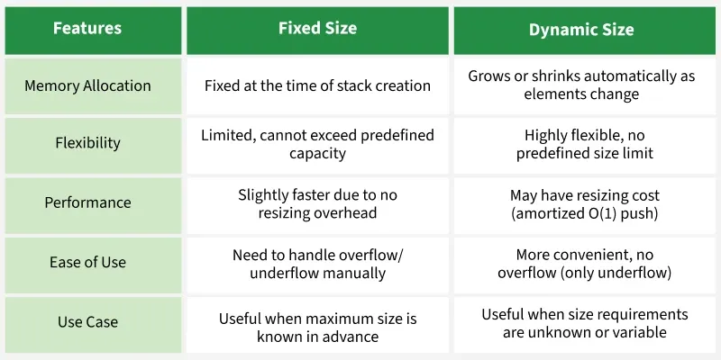